# STT465ProblemSet#2

Sam Isken

September 25, 2019

STT 465 - Fall 2019

Homework 2 - Due 10/02/2019 (In Class)

Instruction: -When using R in any problem, copy the code and results onto your word document under that question number and add any required comments. You will lose points if I do not see your codes.

You should present a stapled document when multiple pages are used. The grader will not be held responsible for any loss of pages.

1. Exercise 3.1 on Page 227 (Textbook)

3.1

Sample Survey: Suppose we are going to sample 100 individuals from a county (of size much larger than 100) and ask each sampled person whether they support policy or not.

Let $Y_i=1$ if person i in the sample supports the policy, and $Y_i=0$ otherwise.

1. Assume $Y_1 , ... Y_n$ are, conditional on $\theta$, i.i.d binary random variable with expectation $\theta$.

Write down the joint distribution of $ Pr(Y_1 = Y_1,…Y_100=y_{100}| ) $

in a compact form.

Also write down the form of

$Pr(_{i=1}^{100}Y_i = y | ) $

The Joint Distribution of $ Pr(Y_1 = Y_1,…Y_100=y_{100}| ) $ is given by:

$$\text{Pr}(Y_i = y|\theta) = {100 \choose y} \theta^y (1-\theta)^{100-y}$$

For the second part of the question let us examine $ Pr(_{i=1}^{100}Y_i = y | ) $

$$Pr(\Sigma_{i=1}^{100}Y_i = y | \theta) = \theta = \theta \Sigma^{100}_{i=1} yi *(1-\theta)^{100} * \Sigma^{100}_{i=1} yi$$

We first examine the Joint Distribution:

$$\text{Pr}(Y_i = y|\theta) = {100 \choose y} \theta^y (1-\theta)^{100-y}$$
For this problem we start back at our joint distribution. We then will assume (given the context of the problem) that

$$\text{Pr(}\Sigma_{i=1}^{100} Y_i = 57 | \theta)$$

for a set of $\theta$’s :

$$\theta \in \{0.0, 0.1, . ,0.9, 1.0\}$$
Thus:

$$\text{Pr}(Y_i = 57|\theta) = {100 \choose 57} \theta^{57} (1-\theta)^{100-57=43}$$

Let us now implement this in R:

```r
#Create set of thetas
theta_set = c(0,.1,.2,.3,.4,.5,.6,.7,.8,.9,1)
#Function to get values of joint pmf given set of thetas
joint_pmf <- function(set_of_theta){
  for (variable in set_of_theta) {
    theta <- variable
    result <- (choose(100,57)) * (theta^(57)) * (1-theta)^(43)
    print(result)
  }
}

joint_pmf(theta_set)
```

```
## [1] 0
## [1] 4.107157e-31
## [1] 3.738459e-16
## [1] 1.306895e-08
## [1] 0.0002285792
## [1] 0.03006864
## [1] 0.06672895
## [1] 0.001853172
## [1] 1.003535e-07
## [1] 9.395858e-18
## [1] 0
```

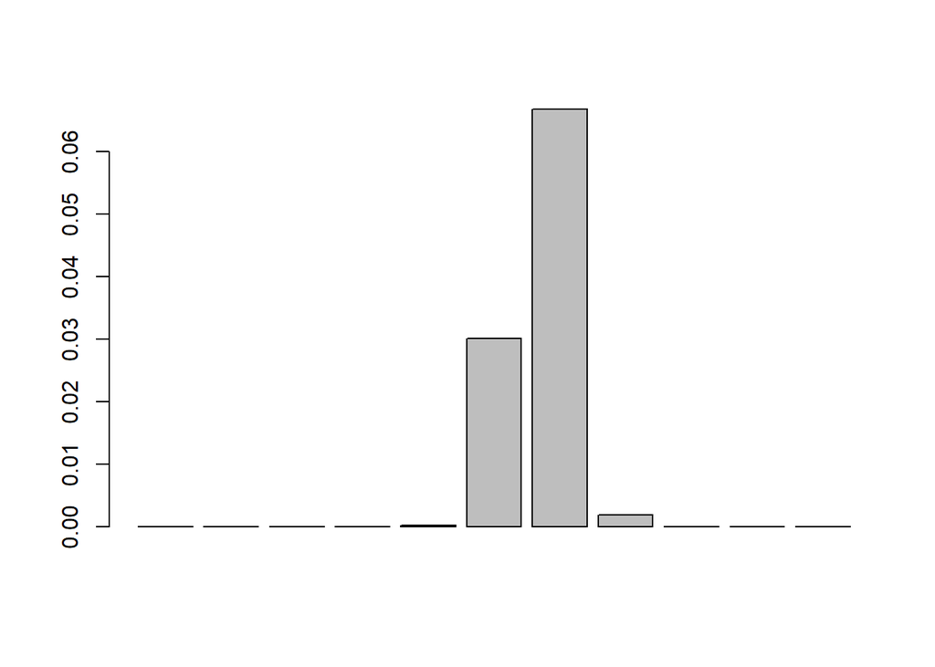

```r
#List of values outputted from functino
fin_list <- c(0,4.107157e-31,3.738459e-16,1.306895e-08,0.0002285792,
              0.03006864,0.06672895,0.001853172,1.003535e-07,9.395858e-18,0)

#plot of posterior distribution
posterior_dist_plot <- barplot(fin_list)
```

3. Now suppose you originally has no prior information to believe one of these $\theta$ values over another, and so Pr($\theta$ = 0.0) = Pr($\theta$ = 0.1) = … = Pr($\theta$ = 0.9) = Pr($\theta$ = 1.0). Use Bayes’ rule to compute Pr($\theta | \Sigma_{i=1}^{100} Y_i = 57$) for each $\theta$ value. Make a plot of this posterior distribution as a function of $\theta$.

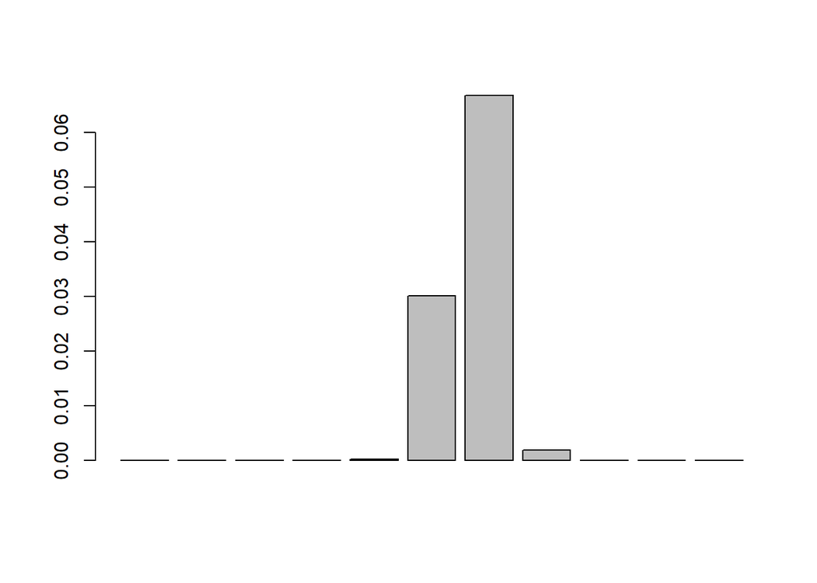

```r
posterior_dist_plot <- barplot(fin_list)
```

Now let us use Bayes’ rule to compute Pr($\theta | \Sigma_{i=1}^{100} Y_i = 57$) for each $\theta$ value.

Since:

```r
print(length(theta_set))
```

```
## [1] 11
```

We assume

$$\text{Pr}(\theta) = 1/11, | \theta \sim \text{}iid$$
And we know:

Posterior Distribution = Prior Distribution * Likelihood Function

Thus:

$$\text{Pr}(\theta|y) = \text(Posterior Distribution) = \frac{{100 \choose 57}\theta^{57} (1-\theta)^{43} (1/11)} {p(y)}$$

This is the desired answer, the posterior distribution.

4. Now suppose you allow $\theta$ to be any value in the interval [0,1]. Using the uniform prior density for $\theta$, so that p($\theta$) = 1, plot the posterior density

p($\theta$) × Pr($\Sigma_{i=1}^{100} Y_i = 57|\theta$)

as a function of $\theta$.

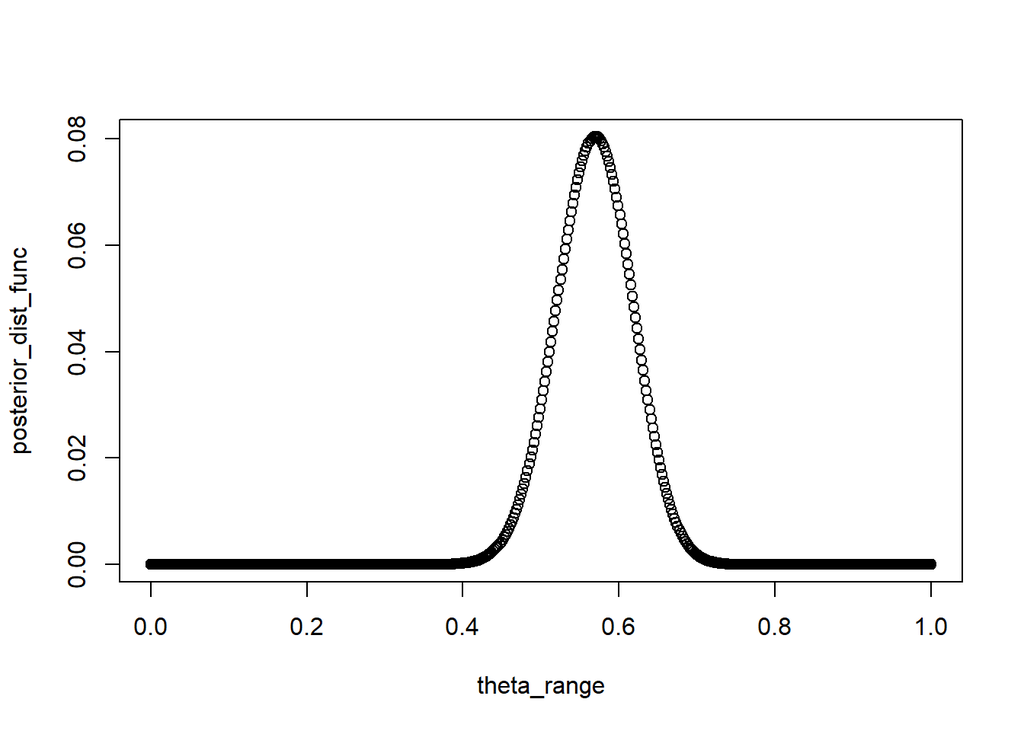

```r
#Set theta to be the range [0,1]
theta_range <- seq(0,1,length=500)
#Set theta probability
prob_theta = 1
posterior_dist_func <- (choose(100,57))*(theta_range^57)*(1-theta_range)^43
#Plot tjos posteriord distribution
plot(theta_range,posterior_dist_func)
```

5. As discussed in this chapter, the posterior distribution of $\theta$ is: beta(1 + 57, 1 + 100 - 57).

Plot the posterior density as a function of $\theta$. Discuss the relationships among all of the plots you have made for this exercise.

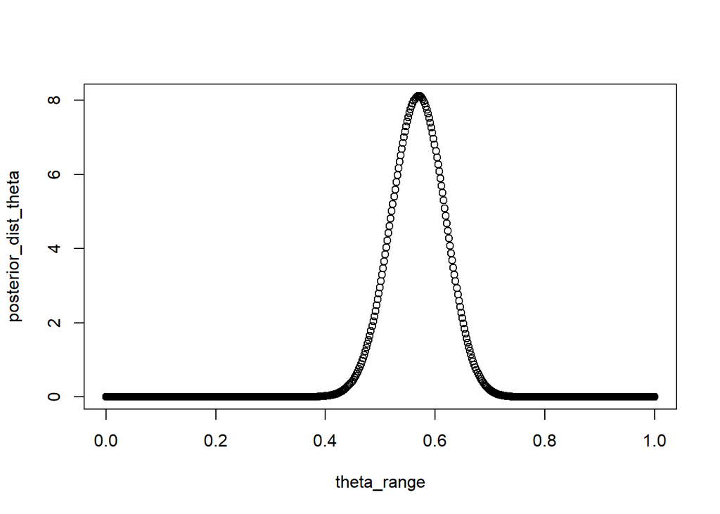

```r
posterior_dist_theta <- dbeta(theta_range,1 + 57, 1 + 100 - 57)
plot(theta_range,posterior_dist_theta)
```

As you can see all of these graphs are equivalent. The posterior distribution of p($\theta$) × Pr($\Sigma_{i=1}^{100} Y_i = 57|\theta$) when plotted is shown to be the same as $\theta$~beta(1 + 57, 1 + 100 - 57). This makes sense as we disscussed the flexibility of the Beta distribution and its similiarity in posteriors to other distributions.

2. The “fish” data set in homework 2 folder on D2L contains data on the # of fish caught by campers in a park.

```r
#Use read csv function in order read in "fish.csv" data set
fish <- read.csv(file = "fish.csv", header = TRUE)
fish
```

```
##     nofish livebait camper persons child           xb           zg count
## 1        1        0      0       1     0 -0.896314561  3.050404787     0
## 2        0        1      1       1     0 -0.558344960  1.746148944     0
## 3        0        1      0       1     0 -0.401731014  0.279938877     0
## 4        0        1      1       2     1 -0.956298113 -0.601525664     0
## 5        0        1      0       1     0  0.436890960  0.527709126     1
## 6        0        1      1       4     2  1.394485474 -0.707534790     0
## 7        0        1      0       3     1  0.184716746 -3.398022175     0
## 8        0        1      0       4     3  2.329106569 -5.450901508     0
## 9        1        0      1       3     2  0.188386485 -1.527417779     0
## 10       0        1      1       1     0  0.287689924  1.393890500     1
## 11       0        1      0       4     1  1.990952730 -1.933189988     0
## 12       0        1      1       3     2  1.317893147 -2.471574545     0
## 13       1        0      0       3     0  0.298041672  1.591265202     1
## 14       0        1      0       3     0  1.290873408  0.829534888     2
```

[output cut: 236 more lines]

1. Present a frequency table using R with observed frequencies for x (x=# of fish caught)

```r
table(fish$count)
```

```
##
##   0   1   2   3   4   5   6   7   8   9  10  11  13  14  15  16  21  22
## 142  31  20  12   6  10   4   3   2   2   1   1   1   1   2   1   2   1
##  29  30  31  32  38  65 149
##   1   1   1   2   1   1   1
```

2. Assuming a Poisson model, provide the maximum likelihood estimate of the Poisson parameter (“lambda”) and an approximate 95% CI.

The PDF of the poisson distribution is given by.

$$p(X = x)=\frac{e^{-\lambda} \cdot \lambda^{x}}{x !}$$

To find the Maximum likelihood estimate of $\lambda$ we must have (for $X_1,X_2,X_3,...,X_n$ iid Poisson RVs) a joint frequency that is the product of the marginal frequency functions, Therefore, the log likelihood is given by:

$$\text{likelihood}(\lambda) = \Sigma_{i=1}^n (X_i \text{log}(\lambda) - \lambda - logX_i!$$

If we simplify further it is clear that:

$$\text{likelihood}(\lambda) = log\lambda\Sigma_{i=1}^n X_i - n\lambda - \Sigma_{i=1}^n logX_i!$$

We know (from STT 442 - Mathematical Statistics) that we find the MLE for an estimator $\lambda$ by taking the first derivitive of a likelihood function and setting it equal to 0:

$$\text{likelihood`}(\lambda) = \frac{1}{\lambda} \Sigma_{i=1}^n - n = 0$$

This implies that the estimate of the estimator $\lambda$ in the Poisson distribution is given by:

$$\hat{\lambda} = \overline{X}$$

Since, under the Poisson distribution:

$$\text{Mean} = \text{Variance} = \hat{\lambda}$$
This implies the 95% CI is given by:

$$\hat{\lambda} \pm 1.96\sqrt{\hat{\lambda}/n}$$

Thus in our case:

```r
#Frequency table
table(fish$count)
```

```
##
##   0   1   2   3   4   5   6   7   8   9  10  11  13  14  15  16  21  22
## 142  31  20  12   6  10   4   3   2   2   1   1   1   1   2   1   2   1
##  29  30  31  32  38  65 149
##   1   1   1   2   1   1   1
```

```r
#Find our lambda hat
lambda_hat <- mean(table(fish$count))
print(lambda_hat)
```

```
## [1] 10
```

```r
#Get length of table, n for CI
n <- length(table(fish$count))
CI = c(lambda_hat-(1.96*sqrt(lambda_hat/n)),lambda_hat+(1.96*sqrt(lambda_hat/n)))
print(CI)
```

```
## [1]  8.760387 11.239613
```

3. Present in a bar-plot the observed frequencies (from question a) and the predicted frequencies according to a Poisson model with a rate parameter equal to the maximum likelihood estimate that you reported in (b).

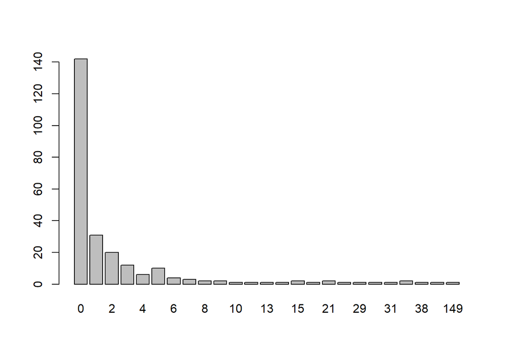

```r
#Bar plot of the observed frequencies
barplot(table(fish$count))
```

```r
#Create vector of categories tp predict
Count_Categories <- c(0,1,2,3,4,5,6,7,8,9,10,11,13,14,15,16,21,22,29,30,31,32,38,65,149)
lambda_hat
```

```
## [1] 10
```

```r
#Create e
e <- exp(1)

poisson_func <- function(Set_of_counts){
  for (variable in Set_of_counts) {
    x <- variable
    result <- (e^(-10) * 10^x)/factorial(x)
    print(result)
  }
}

poisson_func(Count_Categories)
```

```
## [1] 4.539993e-05
## [1] 0.0004539993
## [1] 0.002269996
## [1] 0.007566655
## [1] 0.01891664
## [1] 0.03783327
## [1] 0.06305546
## [1] 0.09007923
## [1] 0.112599
## [1] 0.12511
## [1] 0.12511
## [1] 0.1137364
## [1] 0.07290795
## [1] 0.0520771
## [1] 0.03471807
## [1] 0.02169879
## [1] 0.0008886101
## [1] 0.0004039137
## [1] 5.134715e-07
## [1] 1.711572e-07
## [1] 5.521199e-08
## [1] 1.725375e-08
## [1] 8.6803e-12
## [1] 5.504589e-31
## [1] 1.191936e-116
```

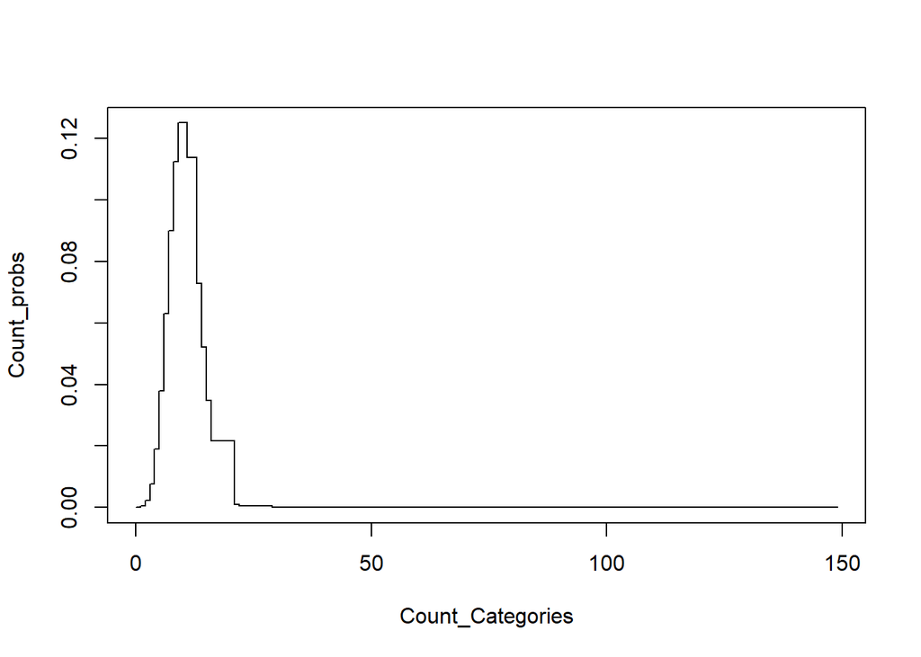

```r
#Out put of function
Count_probs <- c(4.539993e-05,0.0004539993,0.002269996,0.007566655,0.01891664,0.03783327,0.06305546,0.09007923,0.112599,0.12511,0.12511,0.1137364,0.07290795,0.0520771,0.03471807,0.02169879,0.0008886101,0.0004039137,5.134715e-07,1.711572e-07,5.521199e-08,1.725375e-08,8.6803e-12,5.504589e-31,1.191936e-116)

#Plotting predicted values to compare
plot(Count_Categories,Count_probs,type = "s")
```

I plotted the predicted probability of each count above in order to compare with the actual values.

4. Comment the results that you obtained in c. Does the Poisson model fits well this data?

3.6

Exponential family expectation:

Let

$$p(y|\phi)=c(\phi)h(y)exp\{\phi t(y)\}$$
be an exponential family model.

$$\int p(y|\phi)dy=1$$

to show that

$$E [ t(Y)|\phi ] = - \frac{c'(\phi)}{c(\phi)}$$

We begin with:

$$p(y|\phi)=c(\phi)h(y)exp\{\phi t(y)\}$$

Let us now integrate:

$$\frac{d}{d\theta}\int p(y|\phi)dy= 0$$

$$\int \frac{d}{d\theta} p(y|\phi)dy= 0$$

Thus:

$$\int \frac{d^2}{d\theta^2} p(y|\phi)dy= 0$$

Thus for the exponential distribution:
$$\frac{d}{d\theta}p(y|\phi)=[a(y)c(\theta)+c'(\theta)]p(y|\theta)$$
$$\int \frac{d}{d\theta} p(y|\phi)dy= \int[a(y)c(\theta)+c'(\theta)]p(y|\theta)d\theta$$

$$0 = c(\theta)\int a(y)p(y|\theta)dy +c'(\theta)\int p(y|\phi) dy = 0 = c(\theta)E[a(Y)]+c'(\theta)$$

Therefore

$$E [ t(Y)|\phi ] = - \frac{c'(\phi)}{c(\phi)}$$

as desired.

2. Let

$$p(\phi) \propto c(\phi)^{\eta_0}e^{\eta_0 t_0 \phi}$$
be the prior distribution for $\phi$. Calculate $\frac{dp(\phi)}{d\phi}$ and, using the fundemental theorem of calculus disscuss what must be true so that

$$E\left[-\frac{c't(\phi)}{c(\phi)}\right]=t_{0}$$

We know that

$$n_0t_0 + n_0 E\left[-\frac{c't(\phi)}{c(\phi)}\right]=0$$

So

$$\int \frac{dp(\phi)}{d\phi}d\phi = 0$$

must be true to assume

$$E\left[-\frac{c't(\phi)}{c(\phi)}\right]=t_{0}$$

3.9 Galenshore distribution: An unknown quantity Y has a Galenshore($\alpha,\theta$) distribution if its’ density is given by:

$$p(y)=\frac{2}{\Gamma(a)} \theta^{2 a} y^{2 a-1} e^{-\theta^{2} y^{2}}$$

For y>0, $\theta$ >0 and $\alpha$>0. Assume $\alpha$ is known, For this density:

$$E[Y | \theta]=\frac{\Gamma\left(a+\frac{1}{2}\right)}{\theta \Gamma(a)} ; \quad E\left[Y^{2} | \theta\right]=\frac{a}{\theta^{2}}$$

1. Identify a class of conjugate prior densities for $\theta$.

Let us denote a class of conjugate prior densistes for $\theta$ by:

$$\eta(\theta), \theta \sim \text{Galenshore}(c,d)$$

2. Let $Y_1 , ... , Y_n \sim \text{iid Galenshore} (\alpha,\theta)$.

Find the posterior distribution of $\theta$ given $Y_1,...,Y_n$, using a prior from your conjugate class.
$$p(\theta|y_1,...,y_n) \propto \theta^{2a_0 -1}exp{ \{-\theta^2_0 \theta^2 \}} \Pi_{i=1}^n \theta^{2a} exp{ \{-\theta^2y_i^2 \} }$$

which can be further simplified to:

$$\begin{array}{l}{=\theta^{2 a_{0}-1} \exp \left\{-\theta_{0}^{2} \theta^{2}\right\} \theta^{2 n a} \exp \left\{-\theta^{2} \sum_{i=1}^{n} y_{i}^{2}\right\}} \\ {=\theta^{2\left(n a+a_{0}\right)-1} \exp \left\{-\theta^{2}\left(\theta_{0}^{2}+\sum_{i=1}^{n} y_{i}^{2}\right)\right\}}\end{array}$$

3. Write down $\frac{p(\theta_{\alpha} | Y_1 , ..., Y_n)}{p(\theta_b | Y_1,...,Y_n)}$ and simplify. Identify a sufficient statistic.

We can simplify this probability to the following:

$$\begin{aligned} \frac{p\left(\theta_{a} | y_{1}, \ldots, y_{n}\right)}{p\left(\theta_{b} | y_{1}, \ldots, y_{n}\right)} &=\frac{\theta_{a}^{2\left(n a+a_{0}\right)-1} \exp \left\{-\theta_{a}^{2}\left(\theta_{0}^{2}+\sum_{i=1}^{n} y_{i}^{2}\right)\right\}}{\theta_{b}^{2\left(n a+a_{0}\right)-1} \exp \left\{-\theta_{b}^{2}\left(\theta_{0}^{2}+\sum_{i=1}^{n} y_{i}^{2}\right)\right\}} \\ &=\left(\frac{\theta_{a}}{\theta_{b}}\right)^{2\left(n a+a_{0}\right)-1} \exp \left\{-\theta_{0}^{2}\left(\theta_{a}^{2}-\theta_{b}^{2}\right)\right\} \exp \left\{-\sum_{i=1}^{n} y_{i}^{2}\left(\theta_{a}^{2}-\theta_{b}^{2}\right)\right\} \end{aligned}$$

From this we see that $\theta_a/\theta_b$ | y up to $*{i=1}^n y_i^2 $. This implies that $*{i=1}^n y_i^2 $ is a sufficient statistic for $theta$.

4. Determine $E[\theta|y_1,...,y_n]$

$$\mathbb{E}\left[\theta | y_{1}, \ldots, y_{n}\right]=\frac{\Gamma\left(n a+a_{0}+\frac{1}{2}\right)}{\sqrt{\left(\theta_{0}^{2}+\sum_{i=1}^{n} y_{i}^{2}\right)} \Gamma\left(n a+a_{0}\right)}$$